# Project_Policemen

2022-06-17

## Introduction

Being a policeman is a particularly difficult and dangerous job as well. Let us look at the data of all policemen death cases on duty registered in the US from 1791 to 2022.Consequently we will find major groups of the incidents that need to be addressed and likely prevented

## Presentation and description of the problem

Let us anazile given chosen dataset, ordering it by several categories, adding and modifying columns, displaying results in linear, pie chart and histogram.

## Presentation of the data

Each row of the dataset represents one case of policeman’s death. Columns are: * Rank * Name * Cause of death * Date (character)(wday, month, day, year) * Year * Month * Day * Department * State * Boolean value if police was K9 unit

## Data analysis

```r
library(tidyverse)
df1=read.csv("police_deaths_in_america.csv")
class(df1$Date)
```

```
## [1] "character"
```

1. Add column “Day” Since day value is only in Date column, let us add new day column from Date and remove Date column since we will have all values in separate columns

```r
df1 %>% separate(Date, into=c("WDay", "MonthDay", "YearTemp"), sep=", ") %>% select(-starts_with("Day") & -starts_with("YearTemp") )%>% separate(MonthDay, into=c("MonthTemp", "Day"), sep=" ")%>% select(-starts_with("MonthTemp")) ->df2
df2 %>% head()
```

```
##             Rank               Name Cause_of_Death     WDay Day Year    Month
## 1      Constable      Darius Quimby        Stabbed   Monday   3 1791  January
## 2        Sheriff Cornelius Hogeboom        Gunfire Saturday  22 1791  October
## 3 Deputy Sheriff        Isaac Smith        Gunfire Thursday  17 1792      May
## 4        Marshal     Robert Forsyth        Gunfire Saturday  11 1794  January
## 5 Deputy Sheriff     Robert Berwick        Gunfire Thursday  29 1797     June
## 6        Sheriff     Robert Maxwell        Gunfire   Sunday  12 1797 November
##                                                                 Department
## 1                                     Albany County Constable's Office, NY
## 2                                     Columbia County Sheriff's Office, NY
## 3                              Westchester County Sheriff's Department, NY
## 4 United States Department of Justice - United States Marshals Service, US
## 5                                     New York County Sheriff's Office, NY
## 6                                 Washington District Sheriff's Office, SC
##            State K9_Unit
## 1       New York       0
## 2       New York       0
## 3       New York       0
## 4  United States       0
## 5       New York       0
## 6 South Carolina       0
```

1.1 Add State abbreviation

```r
departmentToAbb = \(x){list =str_split(x," ")
  list[[1]][list[[1]]%>%length()]
}
df2%>% rowwise()%>% mutate(Abbreviation=departmentToAbb(Department)) ->df2
```

2. Group entries by Year

```r
df2%>%group_by(Year) %>% summarise(Number=n()) -> byYear
byYear%>% head()
```

```
## # A tibble: 6 x 2
##    Year Number
##   <int>  <int>
## 1  1791      2
## 2  1792      1
## 3  1794      1
## 4  1797      2
## 5  1798      1
## 6  1804      1
```

3. Group by state (select top 20)

```r
df2 %>% mutate(
    State = factor(State)
  ) %>%
  arrange(State) -> byState
byState
```

```
## # A tibble: 26,269 x 11
## # Rowwise:
##    Rank    Name  Cause_of_Death WDay  Day    Year Month Department State K9_Unit
##    <chr>   <chr> <chr>          <chr> <chr> <int> <chr> <chr>      <fct>   <int>
##  1 Consta~ Dari~ Stabbed        Mond~ 3      1791 Janu~ Albany Co~ New ~       0
##  2 Sheriff Corn~ Gunfire        Satu~ 22     1791 Octo~ Columbia ~ New ~       0
##  3 Deputy~ Isaa~ Gunfire        Thur~ 17     1792 May   Westchest~ New ~       0
##  4 Deputy~ Robe~ Gunfire        Thur~ 29     1797 June  New York ~ New ~       0
##  5 Watchm~ Chri~ Stabbed        Thur~ 25     1806 Dece~ New York ~ New ~       0
##  6 Deputy~ Will~ Assault        Frid~ 9      1818 Octo~ Schoharie~ New ~       0
##  7 Watchm~ Luci~ Stabbed        Wedn~ 13     1836 April New York ~ New ~       0
##  8 Watchm~ Kim ~ Stabbed        Sund~ 28     1836 Augu~ New York ~ New ~       0
##  9 Watchm~ Jame~ Fall           Tues~ 25     1839 June  New York ~ New ~       0
## 10 Unders~ Osma~ Gunfire        Thur~ 7      1845 Augu~ Delaware ~ New ~       0
## # ... with 26,259 more rows, and 1 more variable: Abbreviation <chr>
```

```r
df2%>%group_by(State) %>% mutate(Number=n()) %>% ungroup() %>% arrange(desc(Number)) -> df2Temp
df2Temp %>% select(Number) %>% unique() %>% filter(row_number()==20) -> number
df2Temp %>% arrange(Number)
```

```
## # A tibble: 26,269 x 12
##    Rank    Name  Cause_of_Death WDay  Day    Year Month Department State K9_Unit
##    <chr>   <chr> <chr>          <chr> <chr> <int> <chr> <chr>      <chr>   <int>
##  1 Police~ Arth~ Vehicular ass~ Wedn~ 5      1941 Febr~ Panama Ca~ Pana~       0
##  2 Police~ Samu~ Vehicular ass~ Tues~ 28     1945 Augu~ Panama Ca~ Pana~       0
##  3 Police~ Geor~ Vehicular ass~ Thur~ 31     1957 Octo~ Panama Ca~ Pana~       0
##  4 Patrol~ Fasi~ Assault        Sund~ 21     1981 June  American ~ Amer~       0
##  5 Captain Just~ Gunfire        Sund~ 14     1982 Febr~ Northern ~ Nort~       0
##  6 Police~ Abra~ Gunfire        Mond~ 28     1983 Nove~ Northern ~ Nort~       0
##  7 Police~ Gilb~ Gunfire        Mond~ 21     1995 Augu~ Northern ~ Nort~       0
##  8 Police~ Sa F~ Drowned        Wedn~ 3      1998 June  American ~ Amer~       0
##  9 Detect~ Lius~ Gunfire        Thur~ 22     2010 July  American ~ Amer~       0
## 10 Patrol~ Leop~ Motorcycle cr~ Wedn~ 28     1963 Augu~ Virgin Is~ U.S.~       0
## # ... with 26,259 more rows, and 2 more variables: Abbreviation <chr>,
## #   Number <int>
```

```r
df2Temp %>% filter(Number>=as.integer(number)) ->byState
byState %>% head()
```

```
## # A tibble: 6 x 12
##   Rank     Name  Cause_of_Death WDay  Day    Year Month Department State K9_Unit
##   <chr>    <chr> <chr>          <chr> <chr> <int> <chr> <chr>      <chr>   <int>
## 1 Private  Davi~ Gunfire        Satu~ 7      1837 Janu~ Texas Ran~ Texas       0
## 2 Private  Jame~ Gunfire        Satu~ 27     1837 May   Texas Ran~ Texas       0
## 3 Second ~ Alfr~ Assault        Frid~ 10     1837 Nove~ Texas Ran~ Texas       0
## 4 Private  Jess~ Assault        Frid~ 10     1837 Nove~ Texas Ran~ Texas       0
## 5 Private  Alex~ Gunfire        Frid~ 10     1837 Nove~ Texas Ran~ Texas       0
## 6 Private  Jame~ Assault        Frid~ 10     1837 Nove~ Texas Ran~ Texas       0
## # ... with 2 more variables: Abbreviation <chr>, Number <int>
```

4. Group by Rank

```r
df2%>%group_by(Rank) %>% summarise(Number=n()) %>% arrange(desc(Number)) %>% ungroup() -> byRank
byRank%>% head()
```

```
## # A tibble: 6 x 2
##   Rank           Number
##   <chr>           <int>
## 1 Patrolman        3876
## 2 Police Officer   3549
## 3 Deputy Sheriff   3224
## 4 Officer          1746
## 5 Sergeant         1423
## 6 Detective         861
```

5. Group by Month

```r
df2 %>% mutate(
    Month = factor(Month)
  ) %>%
  arrange(Month) -> byMonth
byMonth %>% head()
```

```
## # A tibble: 6 x 11
## # Rowwise:
##   Rank     Name  Cause_of_Death WDay  Day    Year Month Department State K9_Unit
##   <chr>    <chr> <chr>          <chr> <chr> <int> <fct> <chr>      <chr>   <int>
## 1 Constab~ Dari~ Stabbed        Mond~ 3      1791 Janu~ Albany Co~ New ~       0
## 2 Marshal  Robe~ Gunfire        Satu~ 11     1794 Janu~ United St~ Unit~       0
## 3 Deputy ~ Eben~ Assault        Mond~ 18     1808 Janu~ Cumberlan~ Maine       0
## 4 Custom ~ Dani~ Gunfire        Mond~ 1      1810 Janu~ United St~ Unit~       0
## 5 Deputy ~ John~ Gunfire        Mond~ 28     1811 Janu~ Washingto~ Maine       0
## 6 Customs~ John~ Gunfire        Frid~ 21     1814 Janu~ United St~ Unit~       0
## # ... with 1 more variable: Abbreviation <chr>
```

## Data Visualisation

By Year

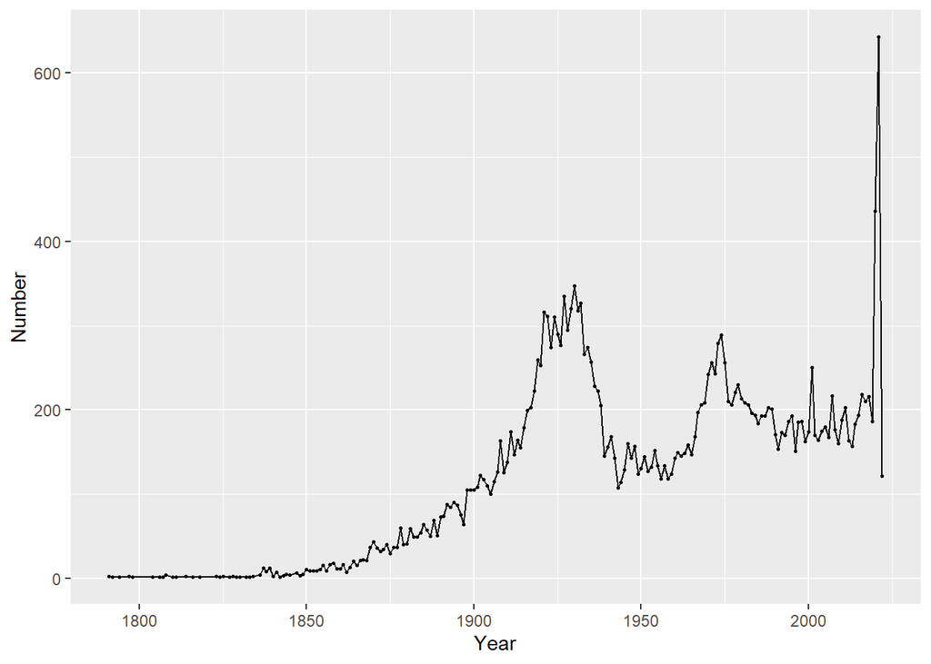

```r
ggplot(data=byYear, mapping=aes(x=Year,
                   y=Number)) +geom_point(size=0.5) + geom_line(aes(x = Year, y = Number))
```

By Month

```r
byMonth
```

```
## # A tibble: 26,269 x 11
## # Rowwise:
##    Rank    Name  Cause_of_Death WDay  Day    Year Month Department State K9_Unit
##    <chr>   <chr> <chr>          <chr> <chr> <int> <fct> <chr>      <chr>   <int>
##  1 Consta~ Dari~ Stabbed        Mond~ 3      1791 Janu~ Albany Co~ New ~       0
##  2 Marshal Robe~ Gunfire        Satu~ 11     1794 Janu~ United St~ Unit~       0
##  3 Deputy~ Eben~ Assault        Mond~ 18     1808 Janu~ Cumberlan~ Maine       0
##  4 Custom~ Dani~ Gunfire        Mond~ 1      1810 Janu~ United St~ Unit~       0
##  5 Deputy~ John~ Gunfire        Mond~ 28     1811 Janu~ Washingto~ Maine       0
##  6 Custom~ John~ Gunfire        Frid~ 21     1814 Janu~ United St~ Unit~       0
##  7 Watchm~ Stev~ Gunfire        Tues~ 8      1828 Janu~ Philadelp~ Penn~       0
##  8 Consta~ Sila~ Stabbed        Thur~ 1      1829 Janu~ Montgomer~ Alab~       0
##  9 Sheriff Will~ Gunfire        Thur~ 23     1834 Janu~ Harrison ~ Indi~       0
## 10 Private Davi~ Gunfire        Satu~ 7      1837 Janu~ Texas Ran~ Texas       0
## # ... with 26,259 more rows, and 1 more variable: Abbreviation <chr>
```

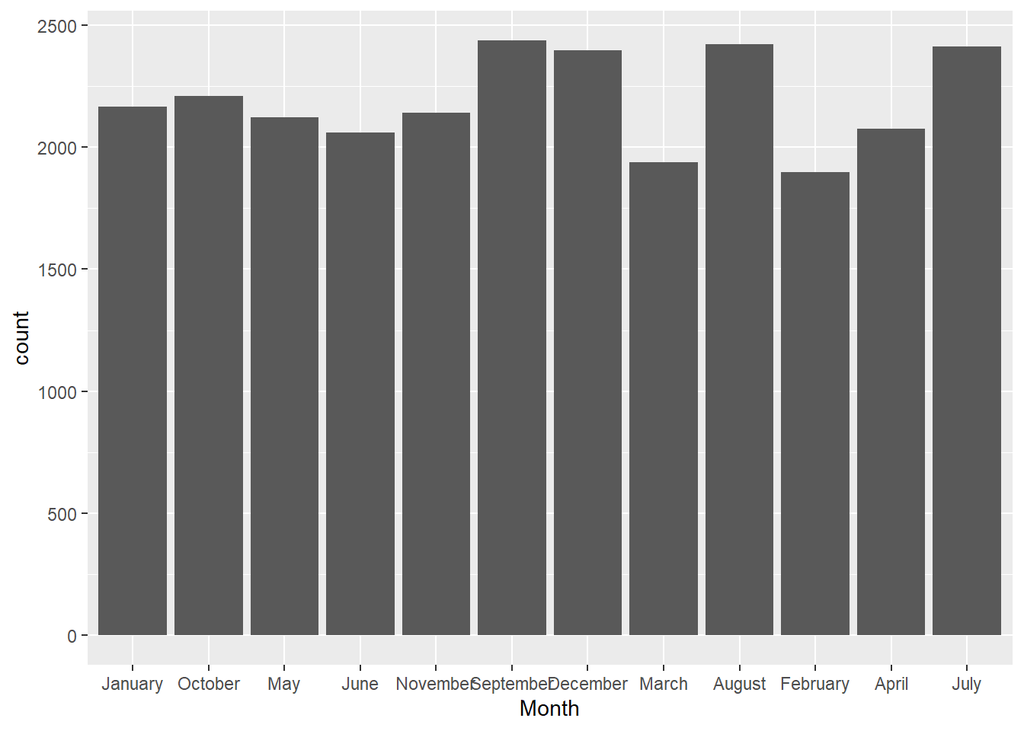

```r
ggplot(byMonth, aes(Month))+geom_bar()
```

By role

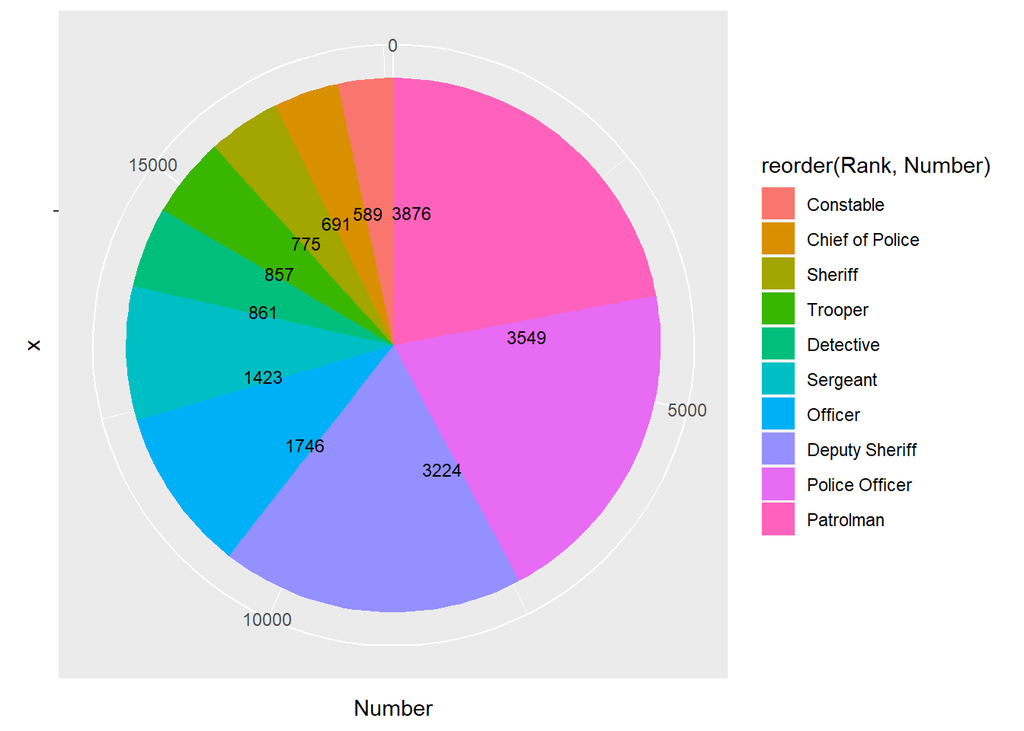

```r
library(scales)
ggplot(byRank%>%top_n(10), aes(x="", y=Number, fill=reorder(Rank, Number))) +geom_col() +
  geom_bar(stat="identity", width=0.5) +
  coord_polar("y", start=0) +geom_text(aes(y = Number/10 + c(0, cumsum(Number)[-length(Number)]),
            label = Number), size=3)
```

By State

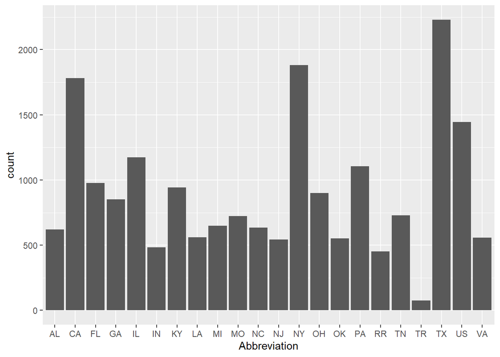

```r
ggplot(byState, aes(Abbreviation))+geom_bar()
```